# L3 R3 - Travaux pratiques

Début avec RMarkdown

automne 2023

Vous allez travailler sur des données issues d’un sondage en cours sur Célène.

# Première séance

- Commencer par récupérer la base de données `sondage_09**.csv`, ainsi que le fichier source RMardown fournis.
- Mettre le .Rmd directment dans votre répertoire de travail et la/les bases de données dans un dossier intitulé `data`.
- Observer les fichiers csv (les ouvrir dans R et non avec un autre logiciel pour ne pas risquer de les modifier).
- Essayer de comprendre le sens et l’intérêt de chaque argument de la commande d’importation de données dans le fichier Rmd.
- Compiler dans RStudio le fichier .Rmd afin d’obtenir une sortie .html.
- Observer en parallèle le fichier source RMarkdown et le document de sortie HTML.

## Premières manipulations en RMarkdown

- Mettre les différents thèmes des questions du sondage sous forme de liste et de sous-listes.
- Choisir des mots à mettre en italique et d’autres à mettre en gras.
- Faire en sorte que l’adresse du site internet de l’université de Tours ne soit pas visible mais cachée derrière une expression cliquable.
- Essayer de comprendre toutes les syntaxes et les commandes du document de base.
- Remplacer les `` `?` `` par une commande de la forme `` `r commande` `` permettant de renvoyer automatiquement la valeur correspondante.
- Dans la partie **Étude des répondants**, réaliser une liste numérotée des différentes questions de la signalétique. La commande `paste()` et ses arguments `sep` et `collapse` peuvent vous être utiles.

## Présentation de tableaux

- Travailler la présentation du tableau des effectifs des répondants par année d’étude en utilisant la commande `kable` du package `knitr`. La fonction `kable` a plusieurs arguments. Les principaux sont : `format`, `digits` qui gère les arrondis, `row.names` et `col.names` qui précisent si le tableau prend en compte les noms de ligne et de colonne, `align` pour préciser comment s’aligne le contenu des colonnes et `caption` pour le titre.
- On peut encore améliorer la présentation grâce à la fonction `kable_styling` du package `kableExtra`. Tester les arguments `full_width = F`, `position = "left"` et `bootstrap_options = c("striped", "hover")`.
- De la même façon, réaliser un tableau de la répartition des genres.
- Puis remplacer ces deux tableaux par un tableau croisé de ces deux variables.

## Un premier graphique

- Ajouter au document un graphique adapté et bien présenté de la répartition des répondants par année d’étude.
- Jouer sur des paramètres pour le rendre le plus lisible possible : orientation, marges (`par(mar = c(...))`), etc.
- Ajouter sur le graphique les effectifs ou les proportions à l’aide de la commande `text`. Des informations sur le graphique peuvent être récupérées en affectant le graphique à un objet.

```r
text( x = vecteur_des_abscisses_de_là_où_on_veut_écrire,
      y = vecteur_des_ordonnées_de_là_où_on_veut_écrire,
                    # utiliser votre tableau d'effectif ou de proportion
      labels = vecteur_de_ce_que_vous_voulez_écrire,
                    # utiliser votre tableau d'effectif ou de proportion
      pos = position_du_texte_par_rapport_au_point,
      col = couleur, cex = # si vous voulez préciser la couleur ou la taille
)
```

- Faire de même pour le genre. Afficher les deux graphiques côte-à-côte.

# Deuxième séance

Lors de cette nouvelle séance, on va commencer par se focaliser sur la structure et la présentation en :

- observant et discutant des modifications de structure dans le nouveau fichier Rmd ;
- en découvrant et utilisant les options de chunks qui vont nous permettre de spécifier si on souhaite ou non voir le code R, les sorties, les messages, etc. ;
- en découvrant et utilisant les paramètres de l’en-tête YAML qui gère la mise en page plus générale du document de sortie.

Puis on reviendra aux tableaux et aux graphiques.

## Bonnes habitudes de structure

- Observer comment a été déplacé/structuré le code produit lors du dernier TP.

## Options de chunk

Vous avez préparé pour cette séance un graphique. La taille de l’image peut être spécifiée en argument du chunk de code produisant le graphique. Par exemple, de la façon suivante : `{r, fig.height = 3, fig.width = 5}`

- Explorer les arguments de chunk suivants : `eval`, `include`, `echo`, `results`, `error`, `message` et `warning`.
- On peut fixer des options par défaut pour tous les chunks suivants avec la commande :

```r
knitr::opts_chunk$set(options à spécifier)
```

Je déconseille de fixer `warning = FALSE`par défaut sur tout le document.

## Présentation générale du document de sortie

La présentation du document de sortie est gérée dans l’entête YAML qui pour l’instant se présente comme ceci :

```r
---
title: "Étude du sondage sur les étudiantes et étudiants de Tours"
author: "Julie Scholler et vous"
date: " "
output: html_document
---
```

- Tester et manipuler les options : `toc`, `toc_float`, `number_section`, `highlight`, `theme`, `df_print`, `dev` et les autres qui vous font envie. Suivre la syntaxe suivante :

```r
---
title: "Étude du sondage sur les étudiantes et étudiants de Tours"
author: "Julie Scholler et vous"
output:
  html_document:
    toc: yes
    toc_float: yes
    ...
---
```

**Attention l’indentation est importante en YAML**

- Tenter une compilation en PDF de votre document. et ajuster les options de présentation pour ce format également. Exemple de syntaxe :

```r
---
title: "Étude du sondage sur les étudiantes et étudiants de Tours"
author: "Julie Scholler et vous"
output:
  pdf_document:
    toc: yes
    number_section: yes
    keep_tex: yes
    highlight: "tango"
    df_print: kable
    dev: png
  html_document:
    toc: yes
    toc_float: yes
    number_section: no
    df_print: paged
    dev: png
---
```

- Pour la création de document en PDF via $\\LaTeX$, certaines options doivent être spécifiée avant `output`. Il s’agit par exemple de `lang`, `fontsize`, `geometry`

```r
---
title: "Étude du sondage sur les étudiantes et étudiants de Tours"
author: "Julie Scholler et vous"
lang: "fr"
fontsize: 11pt
geometry: a4paper,top=2cm,bottom=2cm,left=1.5cm,right=1.5cm
output:
  pdf_document:
    ...
---
```

## Retour aux tableaux et graphiques

- Continuer le travail non fini au TP précédent.

# Troisième séance

À la fin de la première séance, on a vu que l’on était parfois amenés à imbriquer des commandes les unes dans les autres. Cela peut vite devenir lourd et rendre le code difficilement lisible.

## Syntaxe avec *pipe*

Pour rendre ce type de codes (et ainsi la liste des actions appliquées à l’objet) plus intelligible, on peut utiliser les *pipes* avec la commande R : `|>`. Il existe un autre pipe `%>%` qui existe depuis plus longtemps mais qui n’est pas natif, c’est-à-dire qui nécessite de charger un package.

Pour comprendre son fonctionnement, voici des codes équivalents.

```r
# syntaxe de base
f(x, autres arguments)

# équivalent avec l'opérateur |>
x |>
  f(autres arguments)
```

```r
# syntaxe de base
f( g( h (x, autres arguments de h),
      autres arguments de g),
   autres arguments de f)

# équivalent avec l'opérateur |>
x |>
  h(autres arguments de h) |>
  g(autres arguments de g) |>
  f(autres arguments de f)
```

Exemple plus avancé avec *placeholder*

```r
# syntaxe de base
f(x, arg = y)
# équivalent avec l'opérateur |>
y |>  f(x, arg = _)
```

Pour réaliser le *pipe* plus facilement, il existe le raccourci clavier `Ctrl` + `Shift` + `M` ([Pourquoi M ?](https://upload.wikimedia.org/wikipedia/en/b/b9/MagrittePipe.jpg)). Mais par défaut RStudio propose l’autre *pipe* `%>%`. Il faudra donc d’abord sélectionner *Use native pipe operator* dans les `Tools`, `Global Options`, `Code`, `Editing`.

## Retour aux tables

- Commencez par réaliser un tableau croisé de l’e genre’âge et l’année d’étude avec les totaux par ligne et colonne.
- On peut ajouter des sur-titres de colonnes avec la commande `add_header_above` de `kableExtra`.

```r
# syntaxe de base
add_header_above(
  objet kable ou kable_styling,
  c("titre1" = nombre de colonne pour ce titre,
    "titre2" = nombre de colonne pour cet autre titre,...)
)
# syntaxe avec pipe
objet kable ou kable_styling |>
  add_header_above(
    c("titre1" = nombre de colonne pour ce titre,
      "titre2" = nombre de colonne pour cet autre titre,...)
  )
```

- On peut également faire des groupes de lignes avec la commande `pack_rows`.

```r
# syntaxe pour pack_rows
pack_rows(
  objet kable ou kable_styling,
  "titre d'un groupe",
  numéro de la première ligne du groupe, numéro de la dernière ligne du groupe
)
# si on veut plusieurs groupes de lignes, il faut imbriquer les commandes.
```

- Selon l’orientation de votre tableau, utiliser la commande adaptée pour distinguer les âges inférieurs ou égaux à 20 et ceux de plus de 20 ans.
- Explorer les autres fonctions de présentation de tableaux proposées par le package `kableExtra` : http://haozhu233.github.io/kableExtra/.

## Graphiques avancés

Explorer graphiquement :

- la taille des répondants en fonction de leur genre ;
- la taille des répondants en fonction de leur filière ;
- etc.

## Préparation de la suite

- Réfléchir à ce que vous avez envie de regarder dans les données.
- Réfléchir à la gestion des variables :
  - faut-il modifier des noms de variables ? et comment s’y prendre ?
  - faut-il modifier des valeurs/modalités de variables ? et comment ?
  - est-il intéressant de créer de nouvelles variables ou d’en modifier certaines ?

# Quatrième séance

Objectif de cette séance :

- faire le point sur les souhaits de modifications et créations de nouvelles variables
- obtenir de beaux graphiques comme ceux ci-dessou

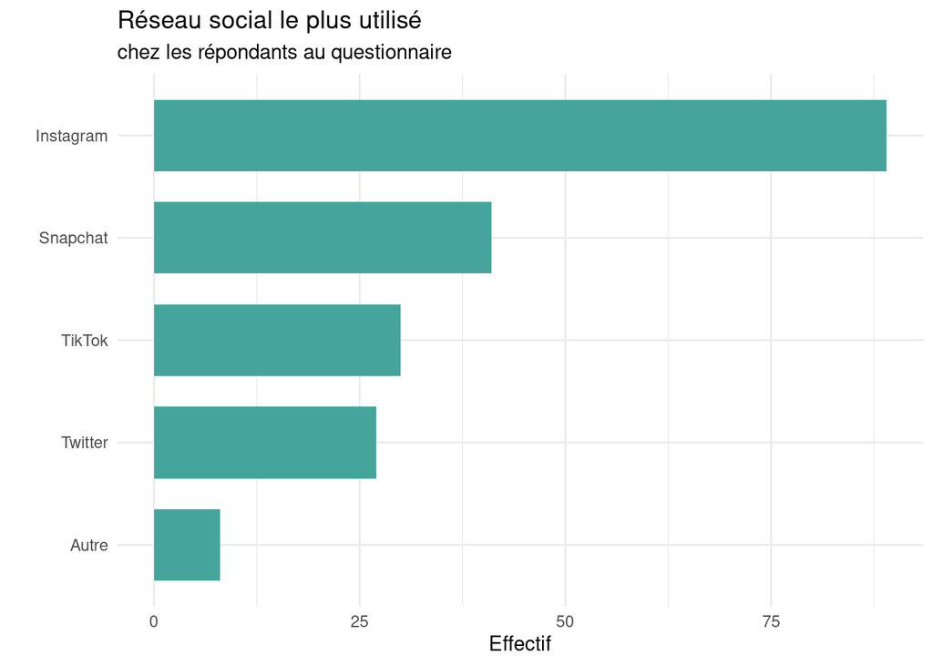

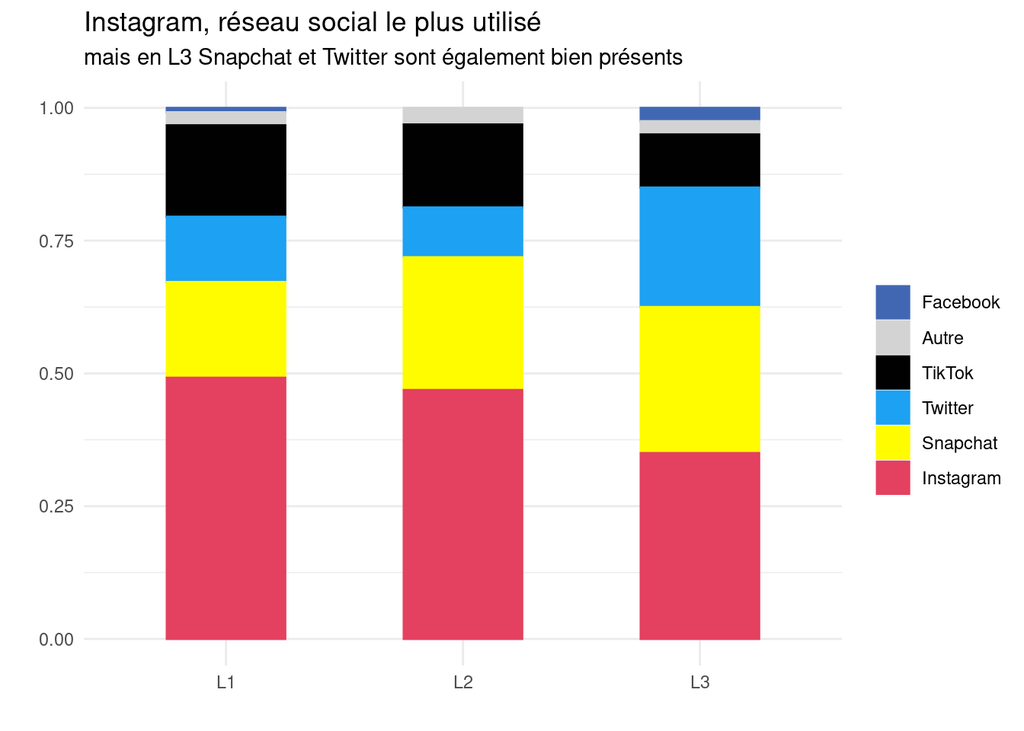

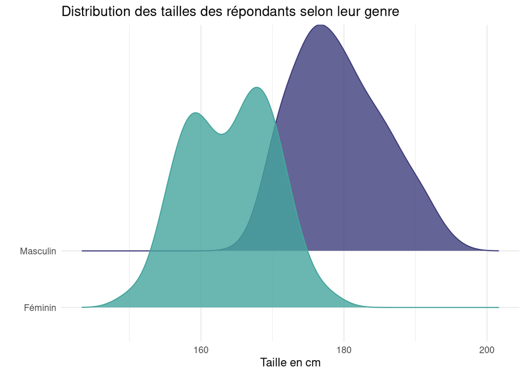

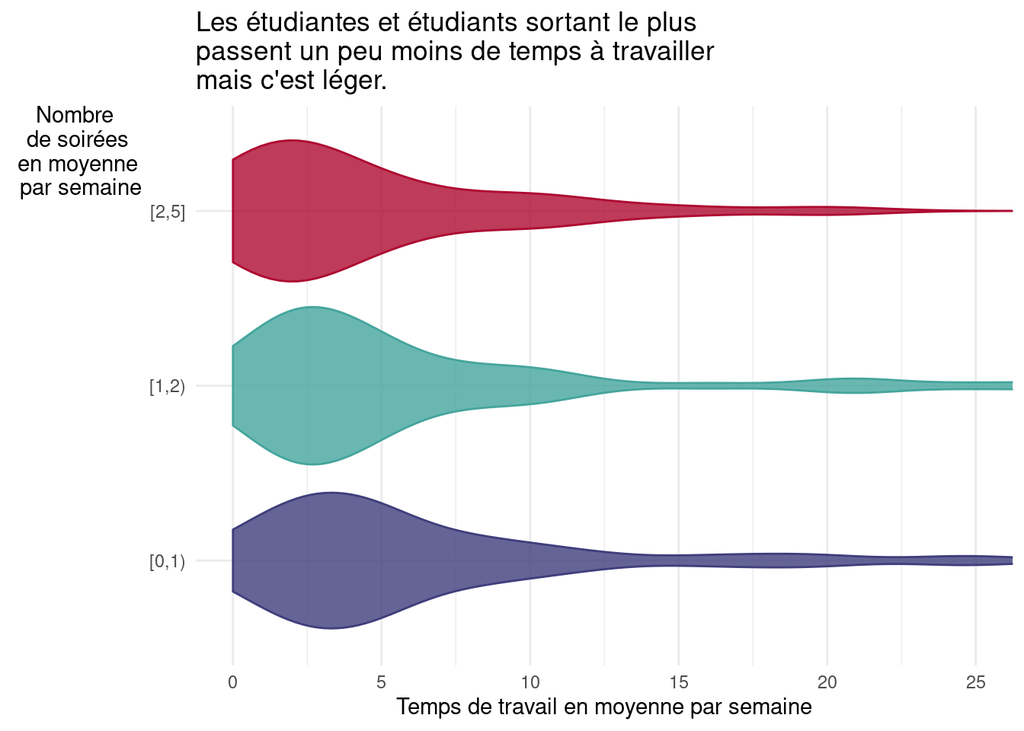

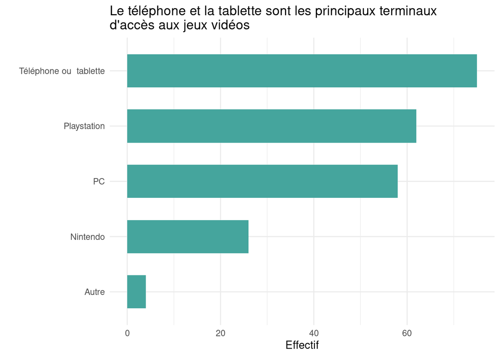

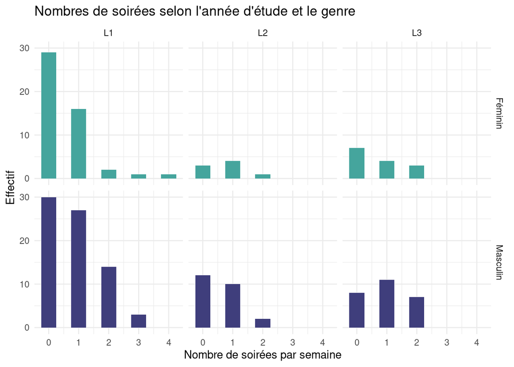

# Cinquième séance

Au cours de cette séance, on va se focaliser sur la préparation de nouvelles variables pour nous faciliter et/ou, tout simplement, nous permettre de faire certaines représentations, certains tableaux, certaines analyses,…

## Manipulation et création de nouvelles variables

Normalement vous avez réfléchi à :

- créer des variables indiquant les différentes modalités cochées pour : les spécialités en terminales, les phobies, les plateformes de jeux vidéos et les sources d’informations ; créer des variables indiquant si les réponses données aux questions de cultures générales sont justes ou fausses ;
- créer une variable indiquant le nombre de phobies ;
- créer une variable indiquant le nombre de bonnes réponses au QCM ;
- créer une variable indiquant la surestiamtion ou sous estimation du nombre de bonnes réponses.

On pourra aussi découper en classes des variables quantitatives.

Dans cet objectif, on va revoir la manipulation de data frame, utiliser éventuellement la nouvelle syntaxe avec `|>`, découvrir de nouvelles fonctions provenant du package `dplyr` et créer des fonctions.

Il s’agit du package axé manipulation de data frame du tidyverse. Une fiche de résumé des principales fonctions de ce package peut se trouver [ici](https://raw.githubusercontent.com/rstudio/cheatsheets/master/data-transformation.pdf).

Le principal avantage de l’utilisation des fonctions du package `dplyr` est la lisibilité du code due à la syntaxe utilisant `|>` et les noms des fonctions qui sont tous des verbes traduisant l’action réalisée par la fonction.

### Sélection de variables avec `dplyr`

Une fonction très importante est `select()` permettant de sélection de variables selon :

- leur position ;
- leur nom exact ;
- le début (`starts_with`), la fin (`ends_with`), une partie (`contains`) de leur nom ;
- une caractéristique quelconque de leur nom avec `matches` et les [expressions régulières](https://github.com/rstudio/cheatsheets/raw/master/regex.pdf).

On pourra utiliser tout cela pour sélectionner les variables correspondant à un thème (à propos de réseaux sociaux, à propos de téléphone, du bac, etc.), etc.

### Syntaxe de création de fonction

de base

```r
ma_fonction <- function(x){
  #actions
  return(objet_à_renvoyer_comme_valeur_de_la_fonction)
}
```

avec plusieurs arguments dont un ayant une valeur spécifiée par défaut

```r
ma_fonction <- function(x, y = val_par_défaut){
  #actions
  return(objet_à_renvoyer_comme_valeur_de_la_fonction)
}
```

### Création et transformation de variables avec `dplyr`

Pour ajouter une ou plusieurs variables à un *data frame*, on peut utiliser la fonction `mutate()`.

Pour transformer des variables, il faut utiliser la fonction `mutate()` en synergie avec `across()`. Par exemple `data |> mutate(across(where(is.character), as.factor))` permet de transformer toutes la variables codées en tant que chaînes de caractères en facteur.

### Sélection d’individus avec `dplyr`

Pour sélectionner des individus/lignes, il existe deux fonctions :

- `slice()` pour découper le *data frame* selon les indices des lignes ;
- `filter()` pour filtrer selon une condition logique.

### Manipulation de facteurs avec le package `forcats`

Dans le package `forcats`, on trouve de nombreuses fonctions pour travailler avec des facteurs.

- `fct_infreq` : réordonne selon la fréquence
- `fct_rev` : inverse l’ordre
- `fct_reorder` : réordonne selon les valeurs pour une autre variable
- `fct_relevel` : réordonne selon un ordre donné à la main
- `fct_lump_*` fusionne des levels automatiquement selon un critère
- `fct_collapse` fusionne des levels en des groupes définis *à la main*

### Graphique

On pourra enfin faire le *magnifique* graphique suivant.

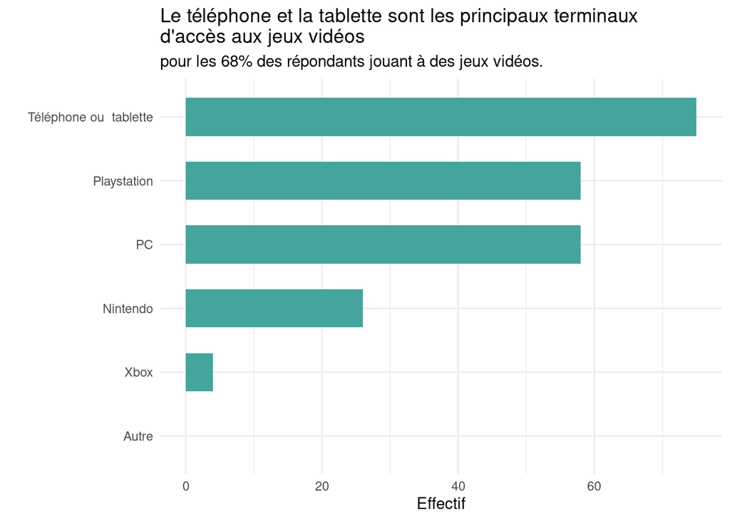

# Sixième séance

Objectifs

- découverte du format `tibble` (un dataframe augmenté)
- tableaux de résumé à la main et avec `modelsummary`
- tests statistiques automatisés
- découpage de variable quantitative en classe

## Format `tibble`

Cette fois pour l’importation j’ai utilisé la commande `read_delim` du package `tibble` de l’écosystème `tidyverse`.

Elle marche de façon similaire à `read.table` sauf qu’en sortie on ne récupère pas un *data.frame* classique mais un *tibble* qui est un *data.frame* permettant les espaces et les caractères spéciaux dans les noms de variables.

## Automatisation d’un tableau de résumé pour les variables quantitatives

- Commençons par la création d’une fonction appelée `resume_var()` qui fournit, sous forme de vecteur, les principaux indicateurs synthétiques de la variable quantitative passée en argument : moyenne, écart type, quartiles.

```r
resume_var <- function(x){
  v <- c(mean(x),
         sd(x),
         quantile(x, seq(0,1,0.25)))
  names(v) <- c("Moyenne", "Écart type",
                "Minimum", "Q1", "Médiane", "Q3", "Maximum")
  return(v)
}
```

- Mettre en application cette commande sur l’age puis la taille.
- Améliorer cette commande pour qu’elle fonctionne sur la taille.
- Utiliser `sapply` pour appliquer la fonction précédente à plusieurs variables quantitatives.
- Écrire une fonction appelée `resume()` qui automatise la question précédente.
- Ajouter un argument pour choisir la précision de l’arrondi.
- Travailler la présentation du tableau obtenu avec `kable()` et `kable_styling()`.
- Écrire une fonction intitulée `kable_plus()` automatisant cette présentation.
- Ajouter un argument logique appelé `transp` qui permet de spécifier si on souhaite que le tableau à présenter soit transposé ou non.

## Utilisation des fonctions du package `modelsummary`

Il existe des fonctions permettant de faire assez automatiquement ce que l’on vient de construire.

- Installer le package `modelsummary` et découvrir les possibilités des fonctions de `datasummary` : https://vincentarelbundock.github.io/modelsummary/articles/datasummary.html
- Tester et comprendre les commandes suivantes.

```r
quanti_var <- c(1, 3, 21, 38, 39)
quali_var <- c(2, 4, 5, 44, 111)
```

```r
datasummary_skim(data[, quanti_var])
datasummary_skim(data[,quali_var], type = "categorical")
```

```r
datasummary(
     Age + `Taille en cm` + phobie_nombre ~ Mean + SD,
    data = data
)
```

- Essayer de changer les noms des colonnes pour mettre `Moyenne` et `Écart type`.
- Tester et comprendre les commandes suivantes.

```r
data$Taille_en_classes <- cut(data$`Taille en cm`,
    breaks = c(140, 160, 180, 200),
    include.lowest = TRUE,
    right = FALSE)
```

```r
datasummary(
     Age + phobie_nombre ~ Mean  *  Taille_cut,
    data = data
)
```

- Essayer de faire en sorte de distinguer en plus en fonction du genre.

## Tests de comparaison de moyenne

On va explorer avec des tests le lien entre la taille et le genre.

- Réaliser un premier test de comparaison des tailles moyennes selon le genre.
- Automatisons maintenant cela avec la fonction suivante.

```r
moy.test.auto <- function(x, y, ...){
  # x une variable quantitative
  # y une variable qualitative binaire
   test <- t.test(x~y, ...)
   output <- c(test$estimate, test$conf.int[1], test$conf.int[2], test$p.value)
   names(output) <- c(names(test$estimate), "Borne inf. de l'IC à 95% de la diff.",
                      "Borne sup. de l'IC à 95% de la diff.", "p-value")
   return(output)
 }
```

- La modifier pour automatiser le choix du test le plus adapté selon les variances des sous-groupes.
- Utiliser `sapply()` pour réaliser plusieurs tests d’un coup.

## Tests d’indépendance

Maintenant on s’intéresse à l’étude du lien entre deux variables qualitatives avec les tests d’indépendance : le genre et l’année d’étude.

- Réaliser un premier test d’indépendance entre le genre et l’année d’étude.

Comme pour les tests de comparaison de moyenne, on peut automatiser cela avec une fonction.

```r
indep.test.auto <- function(x, y, ...){
  # x une variable qualitative
  # y une variable qualitative
   test <- chisq.test(x, y,...)
   output <- c(min(test$expected),  test$p.value)
   names(output) <- c("min. eff.théo", "p-value")
   return(output)
 }
```

- Automatiser, à nouveau, la réalisation de ce type de test et son rendu, afin d’observer les liens entre le genre et de nombreuses autres variables qualitatives.

**Maintenant c’est à vous de travailler !**